# Prepare book datasets

Paolo Martini

2/4/2020

# IRF6KO

#### Donwload the data.

IRF6 Ko dataset can be downloaded from GEO database under accession GSE124048. Raw counts can be downloaded at “ftp://ftp.ncbi.nlm.nih.gov/geo/series/GSE124nnn/GSE124048/suppl/GSE124048_RAW.tar”. We will expand the tar and merge the different samples into a matrix. We will associate to the sample name their phenotypes. We will compute the Differentially expressed genes (DEGs) between WT and IRF6_KO and save results.

#### Download, extract and unzip raw counts.

```bash
wget "ftp://ftp.ncbi.nlm.nih.gov/geo/series/GSE124nnn/GSE124048/suppl/GSE124048_RAW.tar"
tar xf GSE124048_RAW.tar
ls *.tsv.gz | while read file; do gunzip $file; done
```

#### Collapse files into matrix

```r
files_to_process <- dir(pattern = "*.tsv")
tables <- lapply(files_to_process, function(file) {
  read.table(file, header=T, row.names=1, sep="\t", stringsAsFactors = F, check.names = F)
})
samples <- sapply(strsplit(files_to_process, "_"), "[", 1)

counts <- lapply(tables, function(tbl) tbl[,"count",drop=F])

data <- do.call(cbind, counts)
colnames(data) <- samples
```

#### Convert ENSEMBL gene ids to Symbol ID.

```r
ensembl_gene <- row.names(data)

library(org.Mm.eg.db)
library(AnnotationDbi)

id_table_conversion <- select(org.Mm.eg.db, keys=ensembl_gene, columns = c("SYMBOL", "ENTREZID"), keytype="ENSEMBL")
id_conversion <- id_table_conversion[!is.na(id_table_conversion$SYMBOL), ]

data <- data[id_conversion$ENSEMBL, ]

collapsed <- tapply(seq_along(id_conversion$SYMBOL), id_conversion$SYMBOL,
    function(idx) {colMeans(data[idx, ,drop=F])
    }
)

data <- data.frame(do.call(rbind, collapsed))
```

#### Create the sample annotation derive from GEO.

```r
type <- c("GSM3519547"="WT","GSM3519548"="Irf6_KO", "GSM3519549"="WT",
"GSM3519550"="Irf6_KO", "GSM3519551"="Irf6_KO", "GSM3519552"="WT")
sample_info <- data.frame(row.names=names(type), type=type, stringsAsFactors = F)
```

#### Sort the data according to thier type

```r
sample_info <- sample_info[order(sample_info$type),,drop=F]
data <- data[, row.names(sample_info), drop=F]
```

So far, we loaded the data frame composed by 25065 rows (genes) and 6 columns (samples). We associate the phenotype to the colnames and then we reorder columns by the factor. We create an annotation data frame with the “type” of each sample.

#### Filter the raw counts

As a general rule, we filter out the genes with CPM smaller that 0.5 in less than 2 samples. In our dataset, this threshold correspond roughtly to less than 13-15 raw counts.

```r
data <- data.matrix(data)
data_cpm <- edgeR::cpm(data)
keep_cpm <- rowSums(data_cpm >= 0.5) >= 2
data <- data[keep_cpm, , drop=F]
```

#### edgeR differential expression analysis

We came up with 15221 genes and we call edgeR to get the DEGs betwen WT and IRF6KO condition.

```r
suppressPackageStartupMessages(library(edgeR))
design <- model.matrix(~type, data=sample_info)

y <- edgeR::DGEList(counts=data, group=sample_info$type)
y <- edgeR::calcNormFactors(y)
y <- edgeR::estimateGLMCommonDisp(y, design)
y <- edgeR::estimateGLMTagwiseDisp(y, design)

fit <- edgeR::glmFit(y, design)
lrt <- edgeR::glmLRT(fit, coef=2)
table <- edgeR::topTags(lrt, nrow(y))$table
```

#### Normalized counts (cpm)

From y we extract normalized data (cpm and lcpm).

```r
norm_data <- edgeR::cpm(y)
lnorm_data <- edgeR::cpm(y, log=T)
```

#### Extract up and down-regulated genes

```r
up_reg <- table[table$logFC >= 1 & table$FDR <= 0.05, ]
down_reg <- table[table$logFC <= -1 & table$FDR <= 0.05, ]
nrow(up_reg); nrow(down_reg)
```

```
## [1] 1040
```

```
## [1] 476
```

#### Gene wise t-test

We compute t-test pvalue and log fold change for all the genes.

```r
compute_row_ttests <- function(genexsample, classes) {
  cls <- as.numeric(classes)
  apply(genexsample, 1, function(x) {
    t_test <- t.test(x[cls==2], x[cls==1])
    lfc <- log2(mean(x[cls==2])/mean(x[cls==1]))
    data.frame(lfc=lfc, statistic=t_test$statistic, pvalue=t_test$p.value,
               row.names = NULL, stringsAsFactors = F)
  })
}

ttests <- compute_row_ttests(norm_data, factor(sample_info$type))
t_test_df <- do.call(rbind, ttests)
```

#### Save results into a list

We save a list with all the data that will be used for the book examples.

```r
IRF6_dataset <- list(raw_data=data, sample_info=sample_info,
                     edgeR_obj=y,
                     edgeRfit=fit,
                     DE_tables=table,
                     lnorm_data=lnorm_data,
                     norm_data=norm_data,
                     up_down_regulated=list(up=row.names(up_reg),
                                            down=row.names(down_reg)),
                     t_test_df=t_test_df)
save(IRF6_dataset, file="IRF6_dataset.RData")
```

# TCGA ovarian cancer dataset (OV-TCGA)

#### Donwload the data.

A pre compiled version of the TCGA whole dataset can be found in the [MOSClip Tutorial](https://cavei.github.io/MOSClipTutorials/) along with annotations. Please download both in your working directory,

We can load cnv, metCluster, mutations and RNAseq data. Additionally we loaded the panCancerAnnotation that contains annotations from the table by Liu et al, Cell, 2018.

```r
load("TCGA-OV-hg38-preprocessed-externalSurv.RData")
load("panCancerAnnotation.RData")
```

#### Prepare

We prepare a dataset for MOSClip. First we selected from the pancancer annotation the Ovarian Cancer. Then we keep only the patients with TCGa subtipe field define. The we create the common intersection between all the samples with the 4 omics profiled.

```r
ann_OV <- panCancerAnnotation$OV
ann_subtype <- na.omit(ann_OV[, c("TCGA Participant Barcode", "TCGA Subtype"), drop=F])

patients <- ann_subtype$`TCGA Participant Barcode`
survAnnotations <- na.omit(fup$pfs[patients, ])

expression <- rnaSeq
row.names(expression) <- paste0("ENTREZID:", row.names(expression))

mutation <- mutations$data
row.names(mutation) <- paste0("ENTREZID:", row.names(mutation))

names(metClustValues$eMap) <- paste0("ENTREZID:", row.names(metClustValues$eMap))

row.names(cnv) <- paste0("ENTREZID:", row.names(cnv))

patients <- row.names(survAnnotations)
patients <- intersect(patients, colnames(expression))
patients <- intersect(patients, colnames(metClustValues$MET_Cancer_Clustered))
patients <- intersect(patients, colnames(mutation))
patients <- intersect(patients, colnames(cnv))

survAnnot <- survAnnotations[patients, , drop = F]

ann_subtype <- ann_subtype[ann_subtype$`TCGA Participant Barcode` %in% patients, ,drop=F]
patients_subtype <- data.frame(row.names=ann_subtype$`TCGA Participant Barcode`,
                                  subtype=ann_subtype$`TCGA Subtype`)

patients_subtype <- patients_subtype[patients, , drop=F]

expression <- expression[, patients, drop = F]
keep <- apply(expression >= 100, 1, sum) >=30
expression <- expression[keep, , drop=F]

methylation <- metClustValues
methylation$MET_Cancer_Clustered <- methylation$MET_Cancer_Clustered[, patients,
    drop = F]

mutation <- mutation[, patients, drop = F]
cnv <- cnv[, patients, drop = F]

multiOmicDataset = list(expression=expression, methylation=methylation, mutation=mutation, cnv=cnv, patients=patients, patients_subtype=patients_subtype, survAnnot=survAnnot)
save(multiOmicDataset, file="multiOmicDataset.RData")
```

#### Differential expression analysis with edgeR

We run edgeR.

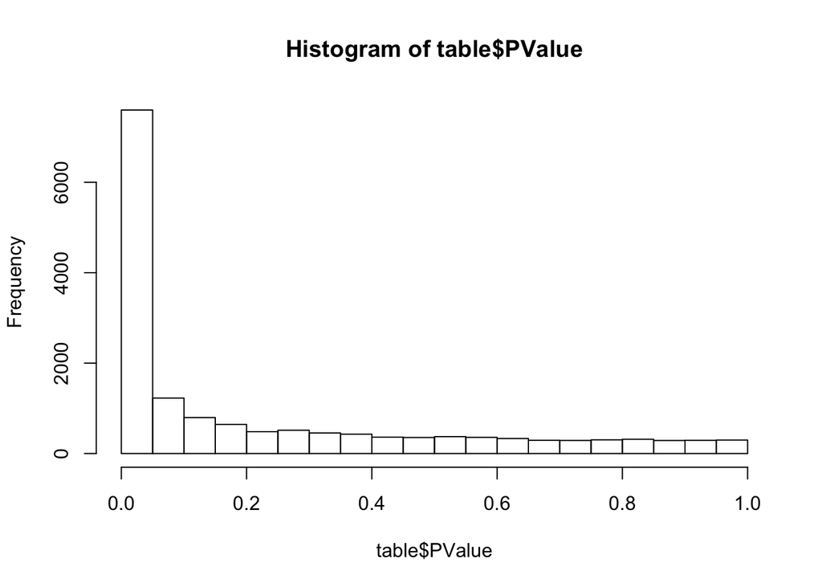

```r
library(edgeR)

patients_subtype = multiOmicDataset$patients_subtype
expression <- multiOmicDataset$expression

design <- model.matrix(~subtype, data=patients_subtype)

y <- edgeR::DGEList(counts=expression, group=patients_subtype$subtype)
y <- edgeR::calcNormFactors(y)
y <- edgeR::estimateGLMCommonDisp(y, design)
y <- edgeR::estimateGLMTagwiseDisp(y, design)

fit <- edgeR::glmFit(y, design)

# OVCA.Proliferative vs OVCA.Differentiated
lrt <- edgeR::glmLRT(fit, coef=4)
table <- edgeR::topTags(lrt, nrow(y))$table
hist(table$PValue)
```

#### Normalized counts (cpm)

We retrieve the normalized data in cpm and log cpm.

```r
norm_data <- edgeR::cpm(y)
lnorm_data <- edgeR::cpm(y, log=T)
```

#### Extract up and down-regulated genes

As previusly shown we extract up and down regulated genes.

```r
up_reg <- table[table$logFC >= 1 & table$FDR <= 0.05, ]
down_reg <- table[table$logFC <= -1 & table$FDR <= 0.05, ]
```

#### Create a reduced dataset for t-test and log fold change computation.

We created a reduced dataset with only Proliferative and Differentiated dataset and compute t-test and log fold change for each gene.

```r
select_columns <- patients_subtype$subtype=="OVCA.Differentiated" | patients_subtype$subtype=="OVCA.Proliferative"

pheno=droplevels(patients_subtype[select_columns, ,drop=F])
pheno <- pheno[order(pheno$subtype), , drop=F]

lnorm_prol_diff <- lnorm_data[, row.names(pheno), drop=F]
norm_prol_diff <- norm_data[, row.names(pheno), drop=F]
annotation_prol_diff <- droplevels(pheno)

row.names(norm_prol_diff) <- gsub("ENTREZID:", "", row.names(norm_prol_diff))

compute_row_ttests <- function(genexsample, classes) {
  cls <- as.numeric(classes)
  apply(genexsample, 1, function(x) {
    t_test <- t.test(x[cls==2], x[cls==1])
    lfc <- log2(mean(x[cls==2])/mean(x[cls==1]))
    data.frame(lfc=lfc, statistic=t_test$statistic, pvalue=t_test$p.value,
               row.names = NULL, stringsAsFactors = F)
  })
}

ttests <- compute_row_ttests(norm_prol_diff, factor(annotation_prol_diff$subtype))
t_test_df_prol_diff <- do.call(rbind, ttests)
```

#### Save a list with the data

We save a dataset that will be used in the book.

```r
degs_up <- gsub("ENTREZID:", "", row.names(up_reg))
degs_down <- gsub("ENTREZID:", "", row.names(down_reg))
row.names(lnorm_data) <- gsub("ENTREZID:", "", row.names(lnorm_data))

TCGA_OV_deg <- list(edgeR_obj=y,
                    edgeRfit=fit,
                    DE_tables=table,
                    lnorm_data=lnorm_data,
                    norm_data=norm_data,
                    lnorm_prol_diff=lnorm_prol_diff,
                    norm_prol_diff=norm_prol_diff,
                    annotation_prol_diff=annotation_prol_diff,
                    up_down_regulated=list(up=degs_up, down=degs_down),
                    t_test_df=t_test_df_prol_diff)

save(TCGA_OV_deg, file="TCGA_OV_deg.RData")
```